# Praktikum3-ModelLag

Siti Keira Zuleyqa

2026-09-10

# library

```r
# install.packages("dLagM")
# install.packages("dynlm")
# install.packages("MLmetrics")
# install.packages("lmtest")
# install.packages("car")
```

# Latihan 1 - Distributed Lag Model

Misalkan terdapat set data pangsa pasar (market share) selama 20 periode dari suatu produk pasta gigi. Akan dilakukan pemodelan distributed lag dari pangsa pasar (Y) terhadap harga (X).

## import data

```r
data1 <- data.frame(
  Period = 1:20,
  Yt = c(3.63, 4.20, 3.33, 4.54, 2.89, 4.87, 4.90, 5.29, 6.18, 7.20,
         7.25, 6.09, 6.80, 8.65, 8.43, 8.29, 7.18, 7.90, 8.45, 8.23),
  Xt = c(0.97, 0.95, 0.99, 0.91, 0.98, 0.90, 0.89, 0.86, 0.85, 0.82,
         0.79, 0.83, 0.81, 0.77, 0.76, 0.80, 0.83, 0.79, 0.76, 0.78)
)
str(data1)
```

```
## 'data.frame':    20 obs. of  3 variables:
##  $ Period: int  1 2 3 4 5 6 7 8 9 10 ...
##  $ Yt    : num  3.63 4.2 3.33 4.54 2.89 4.87 4.9 5.29 6.18 7.2 ...
##  $ Xt    : num  0.97 0.95 0.99 0.91 0.98 0.9 0.89 0.86 0.85 0.82 ...
```

```r
data1
```

```
##    Period   Yt   Xt
## 1       1 3.63 0.97
## 2       2 4.20 0.95
## 3       3 3.33 0.99
## 4       4 4.54 0.91
## 5       5 2.89 0.98
## 6       6 4.87 0.90
## 7       7 4.90 0.89
## 8       8 5.29 0.86
## 9       9 6.18 0.85
## 10     10 7.20 0.82
## 11     11 7.25 0.79
## 12     12 6.09 0.83
## 13     13 6.80 0.81
## 14     14 8.65 0.77
## 15     15 8.43 0.76
## 16     16 8.29 0.80
## 17     17 7.18 0.83
## 18     18 7.90 0.79
## 19     19 8.45 0.76
## 20     20 8.23 0.78
```

## split data

```r
train1 <- data1[1:15,]
test1 <- data1[16:20,]
```

```r
#data time series
train1.ts <- ts(train1)
test1.ts <- ts(test1)
data1.ts <- ts(data1)
```

## Model Koyck

Model Koyck didasarkan pada asumsi bahwa semakin jauh jarak lag peubah independen dari periode sekarang maka semakin kecil pengaruh peubah lag terhadap peubah dependen.

$$y_t=a(1-\lambda)+\beta_0X_t+\lambda
Y_{t-1}+V_t$$

```r
model1.koyck <- koyckDlm(x = train1$Xt, y = train1$Yt)
summary(model1.koyck)
```

```
##
## Call:
## "Y ~ (Intercept) + Y.1 + X.t"
##
## Residuals:
##     Min      1Q  Median      3Q     Max
## -0.9997 -0.3171  0.0652  0.2586  1.1063
##
## Coefficients:
##             Estimate Std. Error t value Pr(>|t|)
## (Intercept)  15.4328    14.7611   1.046    0.318
## Y.1           0.3651     0.5152   0.709    0.493
## X.t         -13.4703    13.8869  -0.970    0.353
##
## Residual standard error: 0.599 on 11 degrees of freedom
## Multiple R-Squared: 0.9037,  Adjusted R-squared: 0.8861
## Wald test: 37.92 on 2 and 11 DF,  p-value: 1.16e-05
##
## Diagnostic tests:
## NULL
##
##                             alpha      beta       phi
## Geometric coefficients:  24.30938 -13.47028 0.3651498
```

```r
AIC(model1.koyck)
```

```
## [1] 30.00231
```

```r
BIC(model1.koyck)
```

```
## [1] 32.55853
```

### forecast

```r
fore1.koyck <- forecast(model = model1.koyck, x = test1$Xt, h = 5)
fore1.koyck
```

```
## $forecasts
## [1] 7.734805 7.076847 7.375405 7.888531 7.806494
##
## $call
## forecast.koyckDlm(model = model1.koyck, x = test1$Xt, h = 5)
##
## attr(,"class")
## [1] "forecast.koyckDlm" "dLagM"
```

```r
mape1.koyck <- MAPE(fore1.koyck$forecasts, test1$Yt)
mape1.koyck
```

```
## [1] 0.05312954
```

```r
#akurasi data training
GoF(model1.koyck)
```

```
##               n       MAE         MPE       MAPE      sMAPE      MASE       MSE
## model1.koyck 14 0.4215632 -0.01898878 0.08448088 0.08112884 0.4555545 0.2818772
##                  MRAE     GMRAE
## model1.koyck 1.457091 0.5463437
```

## Regression with Distributed Lag (DLM)

Pemodelan model Regression with Distributed Lag menggunakan `dLagM::dlm()` dengan beberapa panjang lag ($q$) untuk dibandingkan.

```r
model1.dlm <- dlm(x = train1$Xt, y = train1$Yt, q = 2)
summary(model1.dlm)
```

```
##
## Call:
## lm(formula = model.formula, data = design)
##
## Residuals:
##      Min       1Q   Median       3Q      Max
## -0.55526 -0.24858 -0.08971  0.20176  0.65633
##
## Coefficients:
##              Estimate Std. Error t value Pr(>|t|)
## (Intercept)  26.29549    1.69541  15.510 8.44e-08 ***
## x.t         -24.13651    4.05335  -5.955 0.000214 ***
## x.1          -0.00163    3.20631  -0.001 0.999606
## x.2           0.34290    4.21417   0.081 0.936929
## ---
## Signif. codes:  0 '***' 0.001 '**' 0.01 '*' 0.05 '.' 0.1 ' ' 1
##
## Residual standard error: 0.4366 on 9 degrees of freedom
## Multiple R-squared:  0.9553, Adjusted R-squared:  0.9404
## F-statistic: 64.06 on 3 and 9 DF,  p-value: 2.151e-06
##
## AIC and BIC values for the model:
##        AIC     BIC
## 1 20.56206 23.3868
```

```r
AIC(model1.dlm)
```

```
## [1] 20.56206
```

```r
BIC(model1.dlm)
```

```
## [1] 23.3868
```

### forecast

```r
fore1.dlm <- forecast(model = model1.dlm, x = test1$Xt, h = 5)
fore1.dlm
```

```
## $forecasts
## [1] 7.249082 6.521493 7.500621 8.235068 7.738671
##
## $call
## forecast.dlm(model = model1.dlm, x = test1$Xt, h = 5)
##
## attr(,"class")
## [1] "forecast.dlm" "dLagM"
```

```r
mape1.dlm <- MAPE(fore1.dlm$forecasts, test1$Yt)
mape1.dlm
```

```
## [1] 0.0705934
```

```r
#akurasi data training
GoF(model1.dlm)
```

```
##             n       MAE           MPE       MAPE      sMAPE      MASE       MSE
## model1.dlm 13 0.3009786 -0.0004896023 0.05451787 0.05541524 0.3236329 0.1319396
##                MRAE     GMRAE
## model1.dlm 1.474088 0.3515233
```

## Lag Optimum

```r
#penentuan lag optimum
finiteDLMauto(formula = Yt ~ Xt,
              data = data.frame(train1), q.min = 1, q.max = 6,
              model.type = "dlm", error.type = "AIC", trace = TRUE)
```

```
##   q - k    MASE      AIC      BIC   GMRAE    MBRAE R.Adj.Sq  Ljung-Box
## 6     6 0.08453 -4.06421 -2.28919 0.11903 -0.33129  0.97249 0.04562035
## 3     3 0.27946 14.41990 17.32934 0.49694 -0.34334  0.95685 0.87839563
## 5     5 0.30204 15.91911 18.33979 0.49375 -0.33012  0.89375 0.34730411
## 4     4 0.29388 16.21356 18.99882 0.48458 -0.05971  0.94508 0.68007694
## 1     1 0.35387 19.92429 22.48052 0.47815  1.13162  0.94457 0.32743011
## 2     2 0.32363 20.56206 23.38680 0.35152 -0.40855  0.94035 0.68818708
```

Berdasarkan output tersebut, dipilih lag optimum berdasarkan nilai AIC terkecil. Selanjutnya dilakukan pemodelan ulang menggunakan lag optimum tersebut.

```r
model1.dlm2 <- dlm(x = train1$Xt, y = train1$Yt, q = 6)
summary(model1.dlm2)
```

```
##
## Call:
## lm(formula = model.formula, data = design)
##
## Residuals:
##        1        2        3        4        5        6        7        8
## -0.06257  0.05379  0.06679 -0.05236 -0.03731  0.04871 -0.07404  0.12979
##        9
## -0.07279
##
## Coefficients:
##             Estimate Std. Error t value Pr(>|t|)
## (Intercept)  37.4332     2.7496  13.614   0.0467 *
## x.t         -43.9959     5.1527  -8.538   0.0742 .
## x.1           1.3336     4.4868   0.297   0.8161
## x.2           0.6599     2.9610   0.223   0.8604
## x.3           0.3176     3.5214   0.090   0.9427
## x.4          16.6181     5.4842   3.030   0.2029
## x.5           1.3711     3.0017   0.457   0.7272
## x.6         -13.6131     4.2894  -3.174   0.1943
## ---
## Signif. codes:  0 '***' 0.001 '**' 0.01 '*' 0.05 '.' 0.1 ' ' 1
##
## Residual standard error: 0.2131 on 1 degrees of freedom
## Multiple R-squared:  0.9966, Adjusted R-squared:  0.9725
## F-statistic:  41.4 on 7 and 1 DF,  p-value: 0.1191
##
## AIC and BIC values for the model:
##         AIC       BIC
## 1 -4.064207 -2.289185
```

```r
AIC(model1.dlm2)
```

```
## [1] -4.064207
```

```r
BIC(model1.dlm2)
```

```
## [1] -2.289185
```

###forecast

```r
fore1.dlm2 <- forecast(model = model1.dlm2, x = test1$Xt, h = 5)
fore1.dlm2
```

```
## $forecasts
## [1] 7.728853 6.573892 7.160285 8.510554 8.769298
##
## $call
## forecast.dlm(model = model1.dlm2, x = test1$Xt, h = 5)
##
## attr(,"class")
## [1] "forecast.dlm" "dLagM"
```

```r
mape1.dlm2 <- MAPE(fore1.dlm2$forecasts, test1$Yt)
mape1.dlm2
```

```
## [1] 0.06368703
```

```r
#akurasi data training
GoF(model1.dlm2)
```

```
##             n        MAE           MPE        MAPE       sMAPE       MASE
## model1.dlm2 9 0.06646092 -8.151672e-05 0.009854368 0.009858763 0.08452899
##                     MSE      MRAE     GMRAE
## model1.dlm2 0.005044506 0.1947309 0.1190314
```

## Model Autoregressive (ARDL)

Sebagai pembanding tambahan, dilakukan juga pemodelan Autoregressive Distributed Lag (ARDL), di mana $Y_t$ dipengaruhi oleh $X_t$ pada waktu sekarang maupun lag-nya, serta oleh lag dari $Y_t$ itu sendiri.

$$Y_t = a +
\beta_0X_t+\beta_1X_{t-1}+\phi_1 Y_{t-1}+\varepsilon_t$$

```r
model1.ardl <- ardlDlm(formula = Yt ~ Xt, data = train1, p = 1, q = 1)
summary(model1.ardl)
```

```
##
## Time series regression with "ts" data:
## Start = 2, End = 15
##
## Call:
## dynlm(formula = as.formula(model.text), data = data)
##
## Residuals:
##      Min       1Q   Median       3Q      Max
## -0.50247 -0.30360 -0.05952  0.31335  0.74004
##
## Coefficients:
##             Estimate Std. Error t value Pr(>|t|)
## (Intercept)  18.1366     7.7391   2.344   0.0411 *
## Xt.t        -23.5593     2.8404  -8.294 8.57e-06 ***
## Xt.1          7.2280     7.2307   1.000   0.3411
## Yt.1          0.3028     0.3013   1.005   0.3386
## ---
## Signif. codes:  0 '***' 0.001 '**' 0.01 '*' 0.05 '.' 0.1 ' ' 1
##
## Residual standard error: 0.4177 on 10 degrees of freedom
## Multiple R-squared:  0.9574, Adjusted R-squared:  0.9446
## F-statistic: 74.91 on 3 and 10 DF,  p-value: 3.731e-07
```

```r
AIC(model1.ardl)
```

```
## [1] 20.5772
```

```r
BIC(model1.ardl)
```

```
## [1] 23.77248
```

## forecast

```r
fore1.ardl <- forecast(model = model1.ardl, x = test1$Xt, h = 5)
fore1.ardl
```

```
## $forecasts
## [1] 7.335421 6.586277 7.518614 8.218625 7.742593
##
## $call
## forecast.ardlDlm(model = model1.ardl, x = test1$Xt, h = 5)
##
## attr(,"class")
## [1] "forecast.ardlDlm" "dLagM"
```

```r
mape1.ardl <- MAPE(fore1.ardl$forecasts, test1$Yt)
mape1.ardl #akurasi data test
```

```
## [1] 0.0665442
```

```r
#akurasi data training
GoF(model1.ardl)
```

```
##              n       MAE          MPE       MAPE      sMAPE      MASE       MSE
## model1.ardl 14 0.2976341 -0.001431049 0.05455596 0.05483419 0.3216328 0.1246353
##                 MRAE     GMRAE
## model1.ardl 1.506877 0.3398952
```

## Lag Optimum

Selanjutnya dicari kombinasi orde $p$ (lag X) dan $q$ (lag Y) yang optimum berdasarkan nilai AIC terkecil menggunakan `ardlBoundOrders()`.

```r
#penentuan lag optimum
model1.ardl.opt <- ardlBoundOrders(data = data.frame(train1), ic = "AIC",
                                    formula = Yt ~ Xt, max.p = 4, max.q = 4)
model1.ardl.opt
```

```
## $p
##   Xt
## 1  2
##
## $q
## [1] 1
##
## $Stat.table
##          q = 1    q = 2    q = 3    q = 4
## p = 1 15.07845 11.89200 14.12038 13.43482
## p = 2 11.73291 13.60085 15.18135       NA
## p = 3 15.04581 15.04581 14.50453       NA
##
## $min.Stat
## [1] 11.73291
```

```r
min_p1 <- c()
for (i in 1:4) {
  min_p1[i] <- min(model1.ardl.opt$Stat.table[[i]])
}
q1_opt <- which(min_p1 == min(min_p1, na.rm = TRUE))[1] #ambil 1 nilai jika ada ties
p1_opt <- which(model1.ardl.opt$Stat.table[[q1_opt]] ==
                  min(model1.ardl.opt$Stat.table[[q1_opt]], na.rm = TRUE))[1]

data.frame("q_optimum" = q1_opt, "p_optimum" = p1_opt,
           "AIC" = model1.ardl.opt$min.Stat)
```

```
##   q_optimum p_optimum      AIC
## 1         1         2 11.73291
```

Berdasarkan hasil di atas, didapatkan kombinasi $p$ dan $q$ optimum dengan nilai AIC terkecil. Selanjutnya dilakukan pemodelan ulang menggunakan orde optimum tersebut.

```r
model1.ardl2 <- ardlDlm(formula = Yt ~ Xt, data = train1, p = p1_opt, q = q1_opt)
summary(model1.ardl2)
```

```
##
## Time series regression with "ts" data:
## Start = 3, End = 15
##
## Call:
## dynlm(formula = as.formula(model.text), data = data)
##
## Residuals:
##      Min       1Q   Median       3Q      Max
## -0.48071 -0.21973 -0.05231  0.24589  0.72035
##
## Coefficients:
##             Estimate Std. Error t value Pr(>|t|)
## (Intercept)  19.8812     8.6380   2.302 0.050344 .
## Xt.t        -23.5296     4.2291  -5.564 0.000532 ***
## Xt.1          5.8131     8.3445   0.697 0.505759
## Xt.2         -0.3281     4.4072  -0.074 0.942475
## Yt.1          0.2544     0.3356   0.758 0.470161
## ---
## Signif. codes:  0 '***' 0.001 '**' 0.01 '*' 0.05 '.' 0.1 ' ' 1
##
## Residual standard error: 0.4473 on 8 degrees of freedom
## Multiple R-squared:  0.9583, Adjusted R-squared:  0.9374
## F-statistic: 45.92 on 4 and 8 DF,  p-value: 1.467e-05
```

```r
AIC(model1.ardl2)
```

```
## [1] 21.66028
```

```r
BIC(model1.ardl2)
```

```
## [1] 25.04998
```

```r
fore1.ardl2 <- forecast(model = model1.ardl2, x = test1$Xt, h = 5)
fore1.ardl2
```

```
## $forecasts
## [1] 7.367466 6.627078 7.541175 8.237238 7.782456
##
## $call
## forecast.ardlDlm(model = model1.ardl2, x = test1$Xt, h = 5)
##
## attr(,"class")
## [1] "forecast.ardlDlm" "dLagM"
```

```r
mape1.ardl2 <- MAPE(fore1.ardl2$forecasts, test1$Yt)
mape1.ardl2
```

```
## [1] 0.06265417
```

```r
#akurasi data training
GoF(model1.ardl2)
```

```
##               n       MAE           MPE       MAPE      sMAPE      MASE
## model1.ardl2 13 0.2878165 -0.0007914876 0.05099693 0.05152185 0.3094801
##                    MSE     MRAE     GMRAE
## model1.ardl2 0.1230975 1.392347 0.3251108
```

## Perbandingan Model

```r
akurasi1 <- matrix(c(mape1.koyck, mape1.dlm, mape1.dlm2, mape1.ardl, mape1.ardl2))
row.names(akurasi1) <- c("Koyck", "DLM (q=2)", "DLM (lag optimum)",
                          "ARDL (p=1,q=1)", "ARDL (lag optimum)")
colnames(akurasi1) <- c("MAPE")
akurasi1
```

```
##                          MAPE
## Koyck              0.05312954
## DLM (q=2)          0.07059340
## DLM (lag optimum)  0.06368703
## ARDL (p=1,q=1)     0.06654420
## ARDL (lag optimum) 0.06265417
```

Model terbaik dipilih berdasarkan nilai MAPE terkecil di antara kelima model di atas.

## model terbaik

```r
model1.terbaik <- rownames(akurasi1)[which.min(akurasi1[,"MAPE"])]
cat("Model terbaik untuk Latihan 1 adalah", model1.terbaik,
    "dengan nilai MAPE sebesar", round(min(akurasi1[,"MAPE"]), 5))
```

```
## Model terbaik untuk Latihan 1 adalah Koyck dengan nilai MAPE sebesar 0.05313
```

Berdasarkan output di atas, model dengan nilai MAPE terkecil dipilih sebagai model distributed lag terbaik untuk memodelkan pangsa pasar (Y) terhadap harga (X).

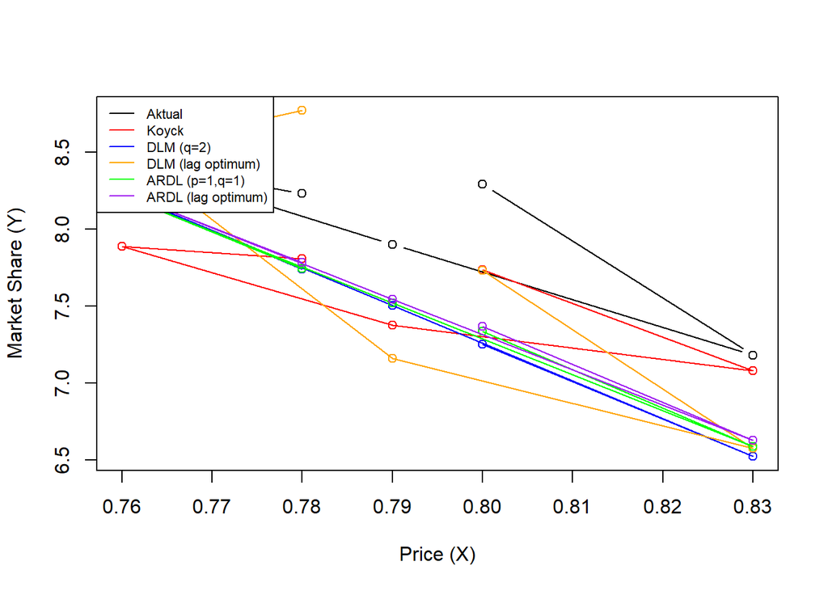

```r
par(mfrow = c(1,1))

plot(test1$Xt, test1$Yt, type = "b", col = "black",
     ylim = range(c(test1$Yt, fore1.koyck$forecasts, fore1.dlm$forecasts,
                     fore1.dlm2$forecasts, fore1.ardl$forecasts, fore1.ardl2$forecasts)),
     xlab = "Price (X)", ylab = "Market Share (Y)")

points(test1$Xt, fore1.koyck$forecasts, col = "red");    lines(test1$Xt, fore1.koyck$forecasts, col = "red")
points(test1$Xt, fore1.dlm$forecasts, col = "blue");     lines(test1$Xt, fore1.dlm$forecasts, col = "blue")
points(test1$Xt, fore1.dlm2$forecasts, col = "orange");  lines(test1$Xt, fore1.dlm2$forecasts, col = "orange")
points(test1$Xt, fore1.ardl$forecasts, col = "green");   lines(test1$Xt, fore1.ardl$forecasts, col = "green")
points(test1$Xt, fore1.ardl2$forecasts, col = "purple"); lines(test1$Xt, fore1.ardl2$forecasts, col = "purple")

legend("topleft",
       c("Aktual", "Koyck", "DLM (q=2)", "DLM (lag optimum)", "ARDL (p=1,q=1)", "ARDL (lag optimum)"),
       lty = 1, col = c("black", "red", "blue", "orange", "green", "purple"), cex = 0.7)
```

## kesimpulan

Kelima model distributed lag menghasilkan nilai MAPE data uji sebagai berikut: Koyck (0.0531), ARDL lag optimum (0.0627), DLM lag optimum (0.0637), ARDL(p=1,q=1) (0.0665), dan DLM(q=2) (0.0706). Model Koyck memberikan nilai MAPE terkecil sehingga dipilih sebagai model terbaik untuk menjelaskan hubungan pangsa pasar (Y) dengan harga (X).

# Latihan 2 - ARDL (Autoregressive Distributed Lag)

Dilakukan pemodelan ARDL yang sesuai menggunakan data penjualan (Sales) sebagai peubah dependen (Y) dan biaya iklan (Advertising) sebagai peubah independen (X) selama tahun 1975-2014.

## import data

```r
data2 <- data.frame(
  Year = 1975:2014,
  Yt = c(11.7, 12.0, 12.3, 12.8, 13.1, 13.6, 13.9, 14.4, 14.7, 15.3,
         15.5, 15.8, 16.1, 16.6, 16.9, 16.7, 16.9, 17.2, 17.6, 17.9,
         18.0, 17.9, 18.0, 18.2, 18.2, 18.3, 18.6, 19.2, 19.3, 19.5,
         19.2, 19.3, 19.5, 20.0, 20.0, 19.9, 19.8, 19.9, 20.2, 21.0),
  Xt = c(9.4, 9.6, 10.0, 10.4, 10.8, 10.9, 11.7, 12.2, 12.5, 12.9,
         13.0, 13.2, 13.8, 14.2, 14.6, 14.4, 15.0, 15.4, 15.7, 15.9,
         15.9, 16.0, 16.3, 16.2, 16.8, 17.3, 17.6, 18.1, 18.3, 18.5,
         18.7, 18.9, 19.2, 20.0, 20.0, 20.3, 20.4, 21.0, 21.5, 22.1)
)
str(data2)
```

```
## 'data.frame':    40 obs. of  3 variables:
##  $ Year: int  1975 1976 1977 1978 1979 1980 1981 1982 1983 1984 ...
##  $ Yt  : num  11.7 12 12.3 12.8 13.1 13.6 13.9 14.4 14.7 15.3 ...
##  $ Xt  : num  9.4 9.6 10 10.4 10.8 10.9 11.7 12.2 12.5 12.9 ...
```

```r
data2
```

```
##    Year   Yt   Xt
## 1  1975 11.7  9.4
## 2  1976 12.0  9.6
## 3  1977 12.3 10.0
## 4  1978 12.8 10.4
## 5  1979 13.1 10.8
## 6  1980 13.6 10.9
## 7  1981 13.9 11.7
## 8  1982 14.4 12.2
## 9  1983 14.7 12.5
## 10 1984 15.3 12.9
## 11 1985 15.5 13.0
## 12 1986 15.8 13.2
## 13 1987 16.1 13.8
## 14 1988 16.6 14.2
```

[output cut: 26 more lines]

## split data

```r
train2 <- data2[1:32,]
test2 <- data2[33:40,]
```

```r
#data time series
train2.ts <- ts(train2)
test2.ts <- ts(test2)
data2.ts <- ts(data2)
```

## Model Autoregressive (ARDL)

Peubah dependen ($Y_t$) dipengaruhi oleh peubah independen pada waktu sekarang ($X_t$), serta oleh peubah dependen itu sendiri pada waktu yang lalu ($Y_{t-1}$).

$$Y_t = a +
\beta_0X_t+\beta_1X_{t-1}+\phi_1 Y_{t-1}+\varepsilon_t$$

```r
model2.ardl <- ardlDlm(formula = Yt ~ Xt, data = train2, p = 1, q = 1)
summary(model2.ardl)
```

```
##
## Time series regression with "ts" data:
## Start = 2, End = 32
##
## Call:
## dynlm(formula = as.formula(model.text), data = data)
##
## Residuals:
##      Min       1Q   Median       3Q      Max
## -0.42335 -0.13904  0.00830  0.09557  0.33510
##
## Coefficients:
##             Estimate Std. Error t value Pr(>|t|)
## (Intercept)  1.32470    0.47181   2.808  0.00915 **
## Xt.t         0.29417    0.15331   1.919  0.06564 .
## Xt.1        -0.18889    0.17157  -1.101  0.28066
## Yt.1         0.83549    0.09927   8.416    5e-09 ***
## ---
## Signif. codes:  0 '***' 0.001 '**' 0.01 '*' 0.05 '.' 0.1 ' ' 1
##
## Residual standard error: 0.1764 on 27 degrees of freedom
## Multiple R-squared:  0.9945, Adjusted R-squared:  0.9939
## F-statistic:  1621 on 3 and 27 DF,  p-value: < 2.2e-16
```

```r
AIC(model2.ardl)
```

```
## [1] -13.87268
```

```r
BIC(model2.ardl)
```

```
## [1] -6.702739
```

### forecast

```r
fore2.ardl <- forecast(model = model2.ardl, x = test2$Xt, h = 8)
fore2.ardl
```

```
## $forecasts
## [1] 19.52778 19.89675 20.05392 20.27348 20.42967 20.71779 20.99225 21.30363
##
## $call
## forecast.ardlDlm(model = model2.ardl, x = test2$Xt, h = 8)
##
## attr(,"class")
## [1] "forecast.ardlDlm" "dLagM"
```

```r
mape2.ardl <- MAPE(fore2.ardl$forecasts, test2$Yt)
mape2.ardl #akurasi data test
```

```
## [1] 0.01932825
```

```r
#akurasi data training
GoF(model2.ardl)
```

```
##              n       MAE           MPE        MAPE      sMAPE      MASE
## model2.ardl 31 0.1340106 -0.0001690312 0.008158669 0.00815532 0.4729786
##                  MSE     MRAE     GMRAE
## model2.ardl 0.027107 70907790 0.7550494
```

## Lag Optimum ($p$ dan $q$)

Selanjutnya dicari kombinasi orde $p$ (lag X) dan $q$ (lag Y) yang optimum berdasarkan nilai AIC terkecil menggunakan `ardlBoundOrders()`.

```r
#penentuan lag optimum
model2.ardl.opt <- ardlBoundOrders(data = data.frame(train2), ic = "AIC",
                                    formula = Yt ~ Xt)
model2.ardl.opt
```

```
## $p
##   Xt
## 1  8
##
## $q
## [1] 9
##
## $Stat.table
##             q = 1      q = 2      q = 3       q = 4      q = 5      q = 6
## p = 1  -12.767556 -10.190107 -11.850312 -11.6021651  -7.491483  -7.062597
## p = 2  -13.411734 -11.431798 -11.945763 -11.2650729  -7.399947  -6.000066
## p = 3   -8.033685  -8.033685 -12.647331 -11.2888984  -7.429764  -5.098755
## p = 4  -10.788032 -10.705025 -10.705025  -9.3150564  -5.506187  -3.108229
## p = 5   -6.135293  -4.280470  -8.545139  -8.5451392  -7.281378  -3.877538
## p = 6   -3.480025  -1.525841  -5.541497  -4.1281270  -4.128127  -2.364002
## p = 7   -5.526457  -4.107380  -8.035245  -6.9597134  -5.146226  -5.146226
## p = 8  -18.886709 -17.067150 -15.093930 -13.4145812 -12.166725 -10.167492
## p = 9  -26.542556 -24.763427 -23.504008 -45.6154971 -68.619099 -98.942881
## p = 10  -4.259597  -2.631358  -1.890529  -0.2382517 -59.521649         NA
## p = 11  -8.416765 -47.282746 -51.809561          NA         NA         NA
## p = 12  -8.018022         NA         NA          NA         NA         NA
##              q = 7      q = 8       q = 9    q = 10    q = 11    q = 12 q = 13
## p = 1   -5.1946166  -8.823828  -11.171692 -18.23253 -16.02191 -25.67619     NA
## p = 2   -3.4269216 -10.042082   -9.787185 -16.58749 -16.66749 -24.43842     NA
## p = 3   -2.1999380  -8.725825   -9.556678 -14.63860 -14.71617        NA     NA
## p = 4   -0.2098053  -6.867875  -11.029092 -25.29853 -29.71813        NA     NA
## p = 5   -0.5012593  -8.240815  -12.710095 -23.36917        NA        NA     NA
## p = 6    1.0660046  -6.522097  -13.561214 -45.22522        NA        NA     NA
## p = 7   -7.5578787 -24.342794  -59.092972        NA        NA        NA     NA
## p = 8  -10.1674918 -25.137299 -103.406051        NA        NA        NA     NA
## p = 9  -96.9432696 -96.943270          NA        NA        NA        NA     NA
## p = 10          NA         NA          NA        NA        NA        NA     NA
## p = 11          NA         NA          NA        NA        NA        NA     NA
## p = 12          NA         NA          NA        NA        NA        NA     NA
##        q = 14 q = 15
## p = 1      NA     NA
## p = 2      NA     NA
## p = 3      NA     NA
## p = 4      NA     NA
## p = 5      NA     NA
## p = 6      NA     NA
## p = 7      NA     NA
## p = 8      NA     NA
## p = 9      NA     NA
## p = 10     NA     NA
## p = 11     NA     NA
## p = 12     NA     NA
##
## $min.Stat
## [1] -103.4061
```

```r
min_p <- c()
for (i in 1:6) {
  min_p[i] <- min(model2.ardl.opt$Stat.table[[i]])
}
q_opt <- which(min_p == min(min_p, na.rm = TRUE))[1] #ambil 1 nilai jika ada ties
p_opt <- which(model2.ardl.opt$Stat.table[[q_opt]] ==
                 min(model2.ardl.opt$Stat.table[[q_opt]], na.rm = TRUE))[1]

data.frame("q_optimum" = q_opt, "p_optimum" = p_opt,
           "AIC" = model2.ardl.opt$min.Stat)
```

```
##   q_optimum p_optimum       AIC
## 1         1         9 -103.4061
```

```r
model2.ardl2 <- ardlDlm(formula = Yt ~ Xt, data = train2, p = p_opt, q = q_opt)
summary(model2.ardl2)
```

```
##
## Time series regression with "ts" data:
## Start = 10, End = 32
##
## Call:
## dynlm(formula = as.formula(model.text), data = data)
##
## Residuals:
##       Min        1Q    Median        3Q       Max
## -0.191789 -0.066528 -0.003262  0.046228  0.282103
##
## Coefficients:
##              Estimate Std. Error t value Pr(>|t|)
## (Intercept)  2.170356   1.623389   1.337  0.20824
## Xt.t         0.440696   0.192099   2.294  0.04247 *
## Xt.1        -0.131295   0.258269  -0.508  0.62124
## Xt.2         0.001906   0.220498   0.009  0.99326
## Xt.3        -0.330153   0.214484  -1.539  0.15199
## Xt.4        -0.079820   0.190005  -0.420  0.68251
## Xt.5         0.131666   0.193368   0.681  0.51001
## Xt.6        -0.131544   0.195040  -0.674  0.51395
## Xt.7         0.111990   0.198587   0.564  0.58411
## Xt.8        -0.387104   0.222364  -1.741  0.10957
## Xt.9         0.418467   0.215959   1.938  0.07875 .
## Yt.1         0.845382   0.225953   3.741  0.00326 **
## ---
## Signif. codes:  0 '***' 0.001 '**' 0.01 '*' 0.05 '.' 0.1 ' ' 1
##
## Residual standard error: 0.157 on 11 degrees of freedom
## Multiple R-squared:  0.9923, Adjusted R-squared:  0.9846
## F-statistic: 129.1 on 11 and 11 DF,  p-value: 5.49e-10
```

```r
AIC(model2.ardl2)
```

```
## [1] -10.87112
```

```r
BIC(model2.ardl2)
```

```
## [1] 3.890307
```

### forecast

```r
fore2.ardl2 <- forecast(model = model2.ardl2, x = test2$Xt, h = 8)
fore2.ardl2
```

```
## $forecasts
## [1] 19.21447 19.42541 19.56640 19.65873 19.60762 19.79429 20.08935 20.41637
##
## $call
## forecast.ardlDlm(model = model2.ardl2, x = test2$Xt, h = 8)
##
## attr(,"class")
## [1] "forecast.ardlDlm" "dLagM"
```

```r
mape2.ardl2 <- MAPE(fore2.ardl2$forecasts, test2$Yt)
mape2.ardl2
```

```
## [1] 0.01568419
```

```r
#akurasi data training
GoF(model2.ardl2)
```

```
##               n        MAE           MPE        MAPE       sMAPE      MASE
## model2.ardl2 23 0.08056482 -4.087364e-05 0.004481326 0.004483715 0.3408511
##                     MSE     MRAE     GMRAE
## model2.ardl2 0.01178451 38539971 0.6218901
```

```r
cons_lm2 <- dynlm(Yt ~ Xt + L(Yt), data = train2.ts)

#autokorelasi
dwtest(cons_lm2)
```

```
##
##  Durbin-Watson test
##
## data:  cons_lm2
## DW = 1.7175, p-value = 0.1235
## alternative hypothesis: true autocorrelation is greater than 0
```

```r
#heteroskedastisitas
bptest(cons_lm2)
```

```
##
##  studentized Breusch-Pagan test
##
## data:  cons_lm2
## BP = 1.9463, df = 2, p-value = 0.3779
```

```r
#normalitas residual
shapiro.test(residuals(cons_lm2))
```

```
##
##  Shapiro-Wilk normality test
##
## data:  residuals(cons_lm2)
## W = 0.98603, p-value = 0.9486
```

- Jika p-value > 0.05 pada uji Durbin-Watson dan Breusch-Pagan → tidak ada autokorelasi/heteroskedastisitas.
- Jika p-value > 0.05 pada uji Shapiro-Wilk → residual berdistribusi normal.

## bandingkan model

```r
akurasi2 <- matrix(c(mape2.ardl, mape2.ardl2))
row.names(akurasi2) <- c("ARDL (p=1,q=1)", "ARDL (lag optimum)")
colnames(akurasi2) <- c("MAPE")
akurasi2
```

```
##                          MAPE
## ARDL (p=1,q=1)     0.01932825
## ARDL (lag optimum) 0.01568419
```

Model terbaik dipilih berdasarkan nilai MAPE terkecil di antara model ARDL awal dan model ARDL dengan orde lag optimum.

## model terbaik

```r
model2.terbaik <- rownames(akurasi2)[which.min(akurasi2[,"MAPE"])]
cat("Model terbaik untuk Latihan 2 adalah", model2.terbaik,
    "dengan nilai MAPE sebesar", round(min(akurasi2[,"MAPE"]), 5))
```

```
## Model terbaik untuk Latihan 2 adalah ARDL (lag optimum) dengan nilai MAPE sebesar 0.01568
```

Berdasarkan output di atas, model dengan nilai MAPE terkecil dipilih sebagai model ARDL terbaik untuk memodelkan penjualan (Y) terhadap biaya iklan (X).

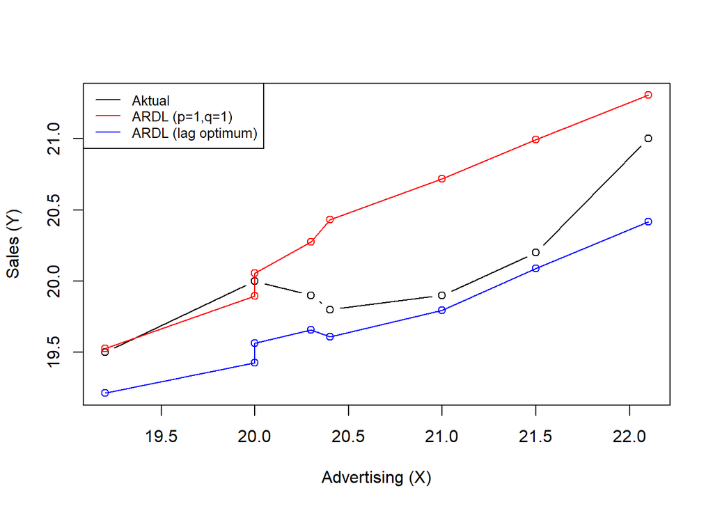

```r
par(mfrow = c(1,1))

plot(test2$Xt, test2$Yt, type = "b", col = "black",
     ylim = range(c(test2$Yt, fore2.ardl$forecasts, fore2.ardl2$forecasts)),
     xlab = "Advertising (X)", ylab = "Sales (Y)")

points(test2$Xt, fore2.ardl$forecasts, col = "red");  lines(test2$Xt, fore2.ardl$forecasts, col = "red")
points(test2$Xt, fore2.ardl2$forecasts, col = "blue"); lines(test2$Xt, fore2.ardl2$forecasts, col = "blue")

legend("topleft",
       c("Aktual", "ARDL (p=1,q=1)", "ARDL (lag optimum)"),
       lty = 1, col = c("black", "red", "blue"), cex = 0.8)
```